# Researcher in Theoretical Physics

Quantum aspects of cosmology and astrophysics from Cambridge to Kraków , sharing news, research and resources…

# Doctor who?

[figure not shown]

Me @ Wolfson College 2026 – Credits: E. Double

[figure not shown]

Research Talk in Paris – Credits: T. Colas

As a Brittany-born Norman French , I was perhaps fated for problems from the start. I spent the first 20 years of my life in Nantes, France, the steampunk city of the North West. My first encounter with space, and most importantly cosmology, was unfortunately NOT while watching the stars, an apple falling from a tree, a rocket launching, or while reading S. Hawking’s *A Brief History of Time*. I like learning and that is about all you need to know.

After realising that zookeeper was not my destiny, that heart surgeon would take too long to study, and that politics… well, anyway, I decided to do something involving maths. Maths were comforting and felt right, until the existential overdose when I realised that maybe I liked it mainly as a tool to answer ‘day-to-day’ questions. I had a great time doing Physics in a Grande Ecole in Paris, followed by a master’s in Cambridge. I started my academic research journey at the former, where I worked on reconstructing the quantum structure of crystals. In Cambridge, I started looking into theoretical physics, and eventually my own series of *why?* questions converged (or diverged?) towards asking *how?* about the whole thing (more commonly called *the Universe*).

In the past 4 years, I studied the early, fast-expanding universe by extending Einstein’s equations of General Relativity to fluctuations generated by the quantum vacuum. In this process, I also looked at the classicalisation of spacetime and have produced and run cutting-edge simulations of the inflating universe (and still do). Pen, paper and supercomputer is a lovely routine of mine.

I am currently transiting from my PhD in Cambridge to a postdoctoral position in Kraków , where I will continue to study quantum corrections to gravitational physics but in a different context: stay tuned!

## News

29/09/2026

Wolfson College interviewed me about my train tour of Europe and the case for greener academic travel, see [article](https://www.wolfson.cam.ac.uk/news/case-greener-academic-travel-yoann-launay).

06/08/2026

My Thesis has been sent to my jury for examination! Viva planned in 2 months.

26/06/2026

After months sending applications, I finally said yes to a postdoctoral position in Krakow, Poland. Stay tuned for more details on a new topic of study!

08/05/2026

My new outreach article for Bluesci on Primordial Black Holes is out! see issue no. 63 [here](https://www.bluesci.co.uk/issue) (page 42).

16/12/2025

My fourth PhD article is out! see [preprint](https://arxiv.org/abs/2512.14649). The final proof of concept of my PhD project is now in the wild.

4/10/2025 – hopefully soon

Postdoc applications in progress…

3/10/2025

End of a great placement, closing with a paper sent to a Machine Learning conference! see submission.

16/03/2025

Now confirmed: as part of my PhD requirements, I will be doing a placement, which I chose to do at [Featurespace](https://www.featurespace.com/) from April and for six months!

12/02/2025

My third PhD article and first with spacetime simulations is out! see [preprint](https://arxiv.org/abs/2502.06783).

11/02/2025

[An interesting article](https://www.intel.com/content/www/us/en/developer/articles/technical/university-cambridge-oneapi-cosmology.html) where my simulations are featured.

05/01/2025

My second PhD article is out! see [preprint](https://arxiv.org/abs/2412.16143).

02/04/2024

I will be one of the Smith-Knight and Rayleigh-Knight 2024 Prize recipients!

16/01/2024

I published my first article in cosmology! see [preprint](https://arxiv.org/abs/2401.08530).

1/11/2023

My first feature article for Bluesci, see issue no. 58 [here](https://www.bluesci.co.uk/issue/article) (page 26).

1/11/2023

New book review article in Bluesci, see issue no. 57 [here](https://www.bluesci.co.uk/issue/article) (page 5).

7/04/2023

G-Research grant obtained! see [article](https://www.gresearch.co.uk/blog/article/g-research-march-2023-grant-winners/).

## Highlights

[figure not shown]

Lessons from an academic tour of Europe by train

August 18, 2026

A month-long, train-only research tour across Europe, and what it taught me about sustainable academia. Featured by Wolfson College.

[figure not shown]

Wolfson Research Event 2026

May 7, 2026

I was invited to present my work at an interdisciplinary conference organised by my College, the Wolfson Research Event.

[figure not shown]

My Thesis in 12 sketches.

February 15, 2024

Twelve hand-drawn sketches summarising my PhD thesis on stochastic inflation and numerical relativity.

## Publications

[figure not shown]

Stochastic scalar-tensor inflation and beyond

Y. Launay · arXiv preprint · 2026-06-05

Extends the stochastic formalism for how quantum vacuum fluctuations become classical during inflation to scalar-tensor theories, covering Gauss-Bonnet, generalized Brans-Dicke, Horndeski and braiding theories, plus multifield coarse-graining in full General Relativity.

[Preprint](https://arxiv.org/abs/2606.07467)

CosmologyInflationStochastic Methods

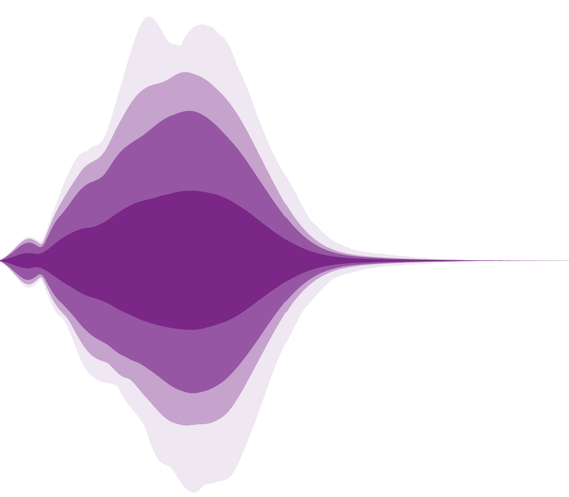

Stochastic Inflation in Numerical Relativity

Y. L. Launay, G. I. Rigopoulos, E. P. S. Shellard · Physical Review D 113 (12), 123515 (2026) · 2025-12-16

Re-derives the 3+1 stochastic inflation equations in a gauge-invariant manner and implements them numerically in the BSSN formulation, showing correct evolution and well-satisfied constraints for slow-roll and ultra-slow-roll scenarios.

[Preprint](https://arxiv.org/abs/2512.14649)[Article](https://doi.org/10.1103/h2cb-q1mt)

CosmologyNumerical RelativityStochastic Methods

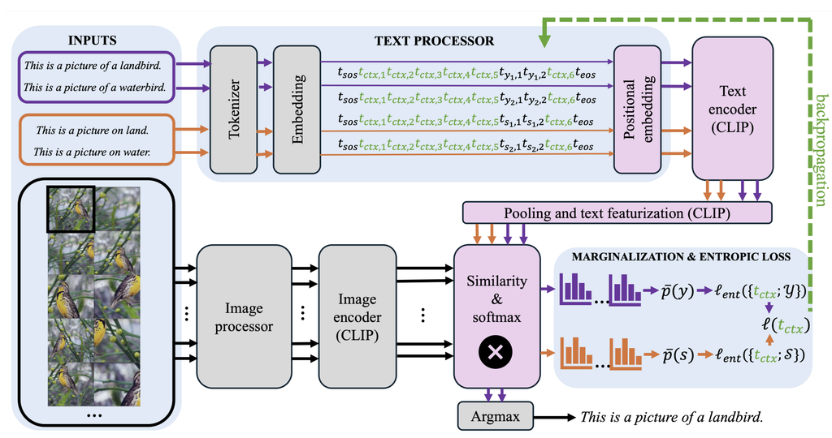

Fairness-Aware Test-Time Prompt Tuning

Y. Launay, P. Kamalaruban, T. Kempton, S. Burrell, D. Sutton · Machine learning conference submission (Featurespace placement, 2025)

[Preprint](https://arxiv.org/abs/2608.25707?ref=taaft&utm_source=taaft&utm_medium=referral)

Machine LearningFairness

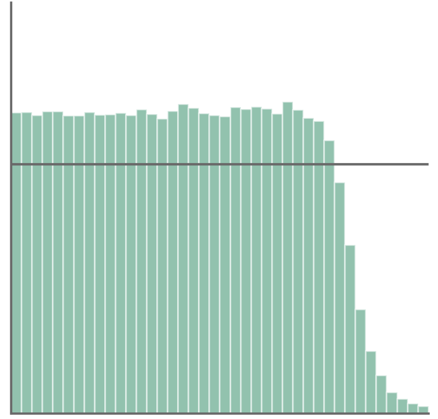

DMAP: A Distribution Map for Text

T. Kempton, J. Rozanova, P. Kamalaruban, M. Madigan, K. Wresilo, Y. L. Launay, D. Sutton, S. Burrell · International Conference on Learning Representations (ICLR) 2026 · 2026-02-12

A technique that maps text, via a language model, to samples encoding rank and probability information, used to validate generation parameters, analyse synthetic-text detection, and uncover statistical patterns in models trained on artificial data.

[Preprint](https://arxiv.org/abs/2602.11871)[Article](https://proceedings.iclr.cc/paper_files/paper/2026/file/594dce834799b064f4584286c33e9d36-Paper-Conference.pdf)

Machine LearningNLP

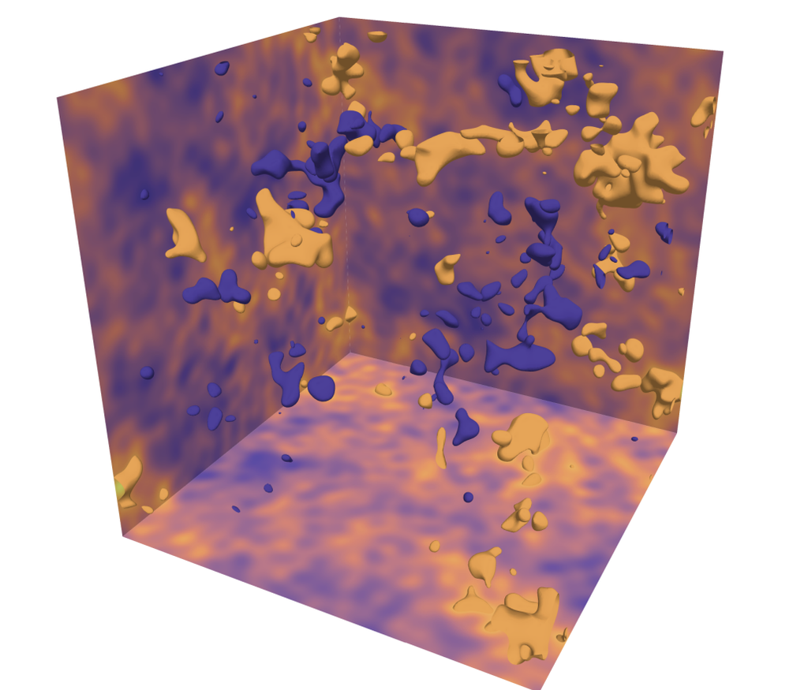

Bunch-Davies initial conditions and non-perturbative inflationary dynamics in Numerical Relativity

Y. L. Launay, G. I. Rigopoulos, E. P. S. Shellard · Physical Review D 112 (4), 043518 (2025) · 2025-02-10

Shows that realistic inhomogeneities during inflation can be simulated with Numerical Relativity from stochastic Bunch-Davies-consistent initial conditions, across a quadratic potential, an inflection-point potential, and a strong resonance model.

[Preprint](https://arxiv.org/abs/2502.06783)[Article](https://doi.org/10.1103/qg66-gxh2)

CosmologyNumerical Relativity

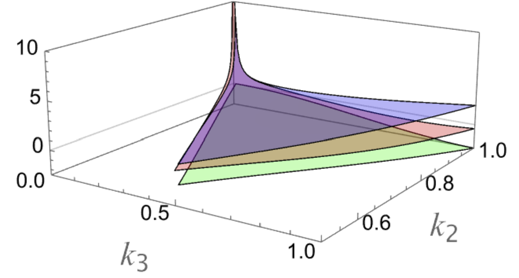

Quantitative classicality in cosmological interactions during inflation

Y. L. Launay, G. I. Rigopoulos, E. P. S. Shellard · Journal of Cosmology and Astroparticle Physics 2025 (05), 071 · 2024-12-20

Introduces a quantitative 'quantum interactivity' measure for when classical descriptions of inflationary perturbations suffice, showing non-linear contributions can be accurately described classically even before horizon crossing.

[Preprint](https://arxiv.org/abs/2412.16143)[Article](https://doi.org/10.1088/1475-7516/2025/05/071)

CosmologyInflation

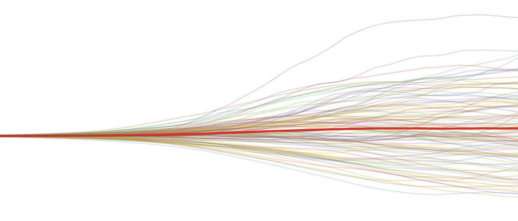

Stochastic Inflation in General Relativity

Y. L. Launay, G. I. Rigopoulos, E. P. S. Shellard · Physical Review D 109 (12), 123523 (2024) · 2024-01-16

Presents a framework for stochastic inflation using complete General Relativity, deriving gauge-invariant Langevin source terms for the Einstein equations in ADM and BSSN formulations, enabling numerical relativity simulations.

[Preprint](https://arxiv.org/abs/2401.08530)[Article](https://doi.org/10.1103/physrevd.109.123523)

CosmologyInflationStochastic Methods

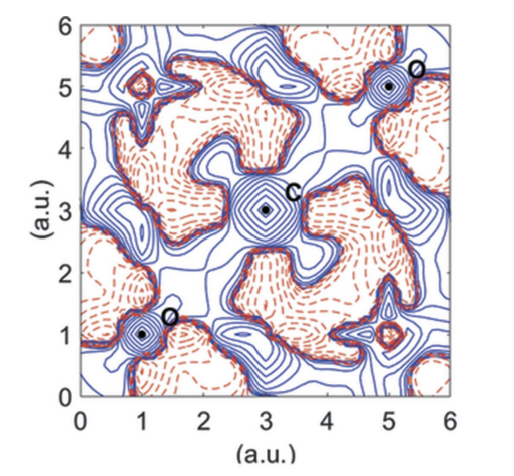

N-representable one-electron reduced density matrices reconstruction at non-zero temperatures

Y. Launay, J.-M. Gillet · Acta Crystallographica Section B: Structural Science, Crystal Engineering and Materials 77 (5), 683-694 · 2021

Reconstructs one-electron reduced density matrices from X-ray structure factors and Compton profiles while accounting for atomic thermal motion, using Semi-Definite Programming to recover static, N-representable matrices from experimental data at non-zero temperature.

[Article](https://doi.org/10.1107/s2052520621007228)

Quantum Crystallography

## They financed or supported my work

- [Featurespace](https://www.featurespace.com/)
- [DiRAC UK](https://dirac.ac.uk/)
- [DAMTP](https://www.damtp.cam.ac.uk/)
- [G-Research](https://www.gresearch.co.uk/)
- [Data-intensive CDT Program](https://cdtdis.bigdata.cam.ac.uk/)
- [UKRI](https://www.ukri.org/)
- [Wolfson College](https://www.wolfson.cam.ac.uk/)

## Contact

Email: yl844 at cam.ac.uk

Office: Center for Mathematical Sciences, Wilberforce Road, Cambridge, CB3 0WA, United Kingdom.